# C5.0 Classification Models

The `C50` package contains an interface to the C5.0 classification model. The main two modes for this model are:

- a basic tree-based model
- a rule-based model

Many of the details of this model can be found in [Quinlan (1993)](https://books.google.com/books?id=b3ujBQAAQBAJ&lpg=PP1&ots=sQ2nTTEpC1&dq=C4.5%3A%20Programs%20for%20Machine%20Learning&lr&pg=PR6#v=onepage&q=C4.5:%20Programs%20for%20Machine%20Learning&f=false) although the model has new features that are described in [Kuhn and Johnson (2013)](http://appliedpredictivemodeling.com/). The main public resource on this model comes from the [RuleQuest website](http://www.rulequest.com/see5-info.html).

To demonstrate a simple model, we’ll use the [credit data](http://bit.ly/2kkBFrk) that can be accessed in the [`recipes` package](https://topepo.github.io/recipes/):

```r
library(recipes)
data(credit_data)
```

The outcome is in a column called `Status` and, to demonstrate a simple model, the `Home` and `Seniority` predictors will be used.

```r
vars <- c("Home", "Seniority")
str(credit_data[, c(vars, "Status")])
```

```
## 'data.frame':    4454 obs. of  3 variables:
##  $ Home     : Factor w/ 6 levels "ignore","other",..: 6 6 3 6 6 3 3 4 3 4 ...
##  $ Seniority: int  9 17 10 0 0 1 29 9 0 0 ...
##  $ Status   : Factor w/ 2 levels "bad","good": 2 2 1 2 2 2 2 2 2 1 ...
```

```r
# a simple split
set.seed(2411)
in_train <- sample(1:nrow(credit_data), size = 3000)
train_data <- credit_data[ in_train,]
test_data  <- credit_data[-in_train,]
```

## Classification Trees

To fit a simple classification tree model, we can start with the non-formula method:

```r
library(C50)
tree_mod <- C5.0(x = train_data[, vars], y = train_data$Status)
tree_mod
```

```
##
## Call:
## C5.0.default(x = train_data[, vars], y = train_data$Status)
##
## Classification Tree
## Number of samples: 3000
## Number of predictors: 2
##
## Tree size: 3
##
## Non-standard options: attempt to group attributes
```

To understand the model, the `summary` method can be used to get the default `C5.0` command-line output:

```r
summary(tree_mod)
```

```
##
## Call:
## C5.0.default(x = train_data[, vars], y = train_data$Status)
##
##
## C5.0 [Release 2.07 GPL Edition]      Fri Dec  1 13:22:24 2017
## -------------------------------
##
## Class specified by attribute `outcome'
##
## Read 3000 cases (3 attributes) from undefined.data
##
## Decision tree:
##
## Seniority > 2: good (1971/396)
## Seniority <= 2:
## :...Home in {ignore,other,priv,rent}: bad (411.4/171)
##     Home in {owner,parents}: good (617.6/226.6)
##
##
## Evaluation on training data (3000 cases):
##
##      Decision Tree
##    ----------------
##    Size      Errors
##
##       3  794(26.5%)   <<
##
##
##     (a)   (b)    <-classified as
##    ----  ----
##     240   623    (a): class bad
##     171  1966    (b): class good
##
##
##  Attribute usage:
##
##  100.00% Seniority
##   34.27% Home
##
##
## Time: 0.0 secs
```

A graphical method for examining the model can be generated by the `plot` method:

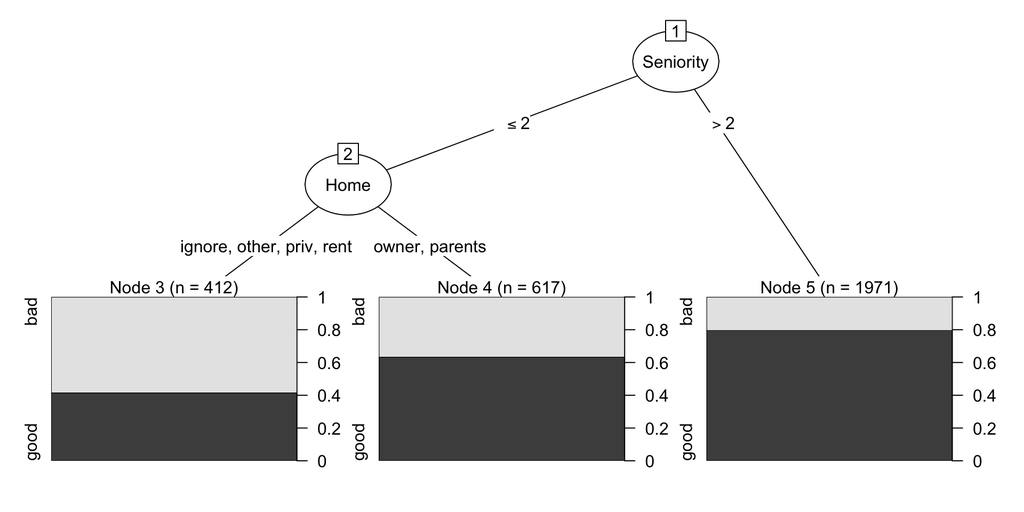

```r
plot(tree_mod)
```

A variety of options are outlines in the documentation for `C5.0Control` function. Another option that can be used is the `trials` argument which enables a boosting procedure. This method is model similar to AdaBoost than to more statistical approaches such as stochastic gradient boosting.

For example, using three iterations of boosting:

```r
tree_boost <- C5.0(x = train_data[, vars], y = train_data$Status, trials = 3)
summary(tree_boost)
```

```
##
## Call:
## C5.0.default(x = train_data[, vars], y = train_data$Status, trials = 3)
##
##
## C5.0 [Release 2.07 GPL Edition]      Fri Dec  1 13:22:24 2017
## -------------------------------
##
## Class specified by attribute `outcome'
##
## Read 3000 cases (3 attributes) from undefined.data
##
## -----  Trial 0:  -----
##
## Decision tree:
##
## Seniority > 2: good (1971/396)
## Seniority <= 2:
## :...Home in {ignore,other,priv,rent}: bad (411.4/171)
##     Home in {owner,parents}: good (617.6/226.6)
##
## -----  Trial 1:  -----
##
## Decision tree:
##
## Seniority > 5: good (1331.5/339.5)
## Seniority <= 5:
## :...Seniority <= 0: bad (392.4/173)
##     Seniority > 0: good (1276.1/542.7)
##
## -----  Trial 2:  -----
##
## Decision tree:
##  good (2426/564.2)
##
##
## Evaluation on training data (3000 cases):
##
## Trial        Decision Tree
## -----      ----------------
##    Size      Errors
##
##    0      3  794(26.5%)
##    1      3  843(28.1%)
##    2      1  863(28.8%)
## boost            803(26.8%)   <<
##
##
##     (a)   (b)    <-classified as
##    ----  ----
##     103   760    (a): class bad
##      43  2094    (b): class good
##
##
##  Attribute usage:
##
##  100.00% Seniority
##   34.27% Home
##
##
## Time: 0.0 secs
```

Note that the counting is zero-based. The `plot` method can also show a specific tree in the ensemble using the `trial` option.

# Rule-Based Models

C5.0 can create an initial tree model then decompose the tree structure into a set of mutually exclusive rules. These rules can then be pruned and modified into a smaller set of *potentially* overlapping rules. The rules can be created using the `rules` option:

```r
rule_mod <- C5.0(x = train_data[, vars], y = train_data$Status, rules = TRUE)
rule_mod
```

```
##
## Call:
## C5.0.default(x = train_data[, vars], y = train_data$Status, rules = TRUE)
##
## Rule-Based Model
## Number of samples: 3000
## Number of predictors: 2
##
## Number of Rules: 3
##
## Non-standard options: attempt to group attributes
```

```r
summary(rule_mod)
```

```
##
## Call:
## C5.0.default(x = train_data[, vars], y = train_data$Status, rules = TRUE)
##
##
## C5.0 [Release 2.07 GPL Edition]      Fri Dec  1 13:22:25 2017
## -------------------------------
##
## Class specified by attribute `outcome'
##
## Read 3000 cases (3 attributes) from undefined.data
##
## Rules:
##
## Rule 1: (411/171, lift 2.0)
##  Home in {ignore, other, priv, rent}
##  Seniority <= 2
##  ->  class bad  [0.584]
##
## Rule 2: (1971/396, lift 1.1)
##  Seniority > 2
##  ->  class good  [0.799]
##
## Rule 3: (1940/423, lift 1.1)
##  Home in {owner, parents}
##  ->  class good  [0.782]
##
## Default class: good
##
##
## Evaluation on training data (3000 cases):
##
##          Rules
##    ----------------
##      No      Errors
##
##       3  794(26.5%)   <<
##
##
##     (a)   (b)    <-classified as
##    ----  ----
##     240   623    (a): class bad
##     171  1966    (b): class good
##
##
##  Attribute usage:
##
##   79.40% Seniority
##   78.37% Home
##
##
## Time: 0.0 secs
```

Note that no pruning was warranted for this model.

There is no `plot` method for rule-based models.

# Predictions

The `predict` method can be used to get hard class predictions or class probability estimates (aka “confidence values” in documentation).

```r
predict(rule_mod, newdata = test_data[1:3, vars])
```

```
## [1] good bad  good
## Levels: bad good
```

```r
predict(tree_boost, newdata = test_data[1:3, vars], type = "prob")
```

```
##         bad      good
## 3 0.0000000 1.0000000
## 4 0.5981465 0.4018535
## 7 0.0000000 1.0000000
```

# Cost-Sensitive Models

A cost-matrix can also be used to emphasize certain classes over others. For example, to get model of the “bad” samples:

```r
cost_mat <- matrix(c(0, 2, 1, 0), nrow = 2)
rownames(cost_mat) <- colnames(cost_mat) <- c("bad", "good")
cost_mat
```

```
##      bad good
## bad    0    1
## good   2    0
```

```r
cost_mod <- C5.0(x = train_data[, vars], y = train_data$Status,
                 costs = cost_mat)
summary(cost_mod)
```

```
##
## Call:
## C5.0.default(x = train_data[, vars], y = train_data$Status, costs
##  = cost_mat)
##
##
## C5.0 [Release 2.07 GPL Edition]      Fri Dec  1 13:22:25 2017
## -------------------------------
##
## Class specified by attribute `outcome'
##
## Read 3000 cases (3 attributes) from undefined.data
## Read misclassification costs from undefined.costs
##
## Decision tree:
##
## Seniority <= 2: bad (1029/562)
## Seniority > 2:
## :...Home in {ignore,owner,parents}: good (1331.7/199.4)
##     Home in {other,priv,rent}:
##     :...Seniority > 15: good (130/21)
##         Seniority <= 15:
##         :...Seniority <= 5: bad (199.6/116.3)
##             Seniority > 5: good (309.6/92.3)
##
##
## Evaluation on training data (3000 cases):
##
##         Decision Tree
##    -----------------------
##    Size      Errors   Cost
##
##       5  991(33.0%)   0.43   <<
##
##
##     (a)   (b)    <-classified as
##    ----  ----
##     550   313    (a): class bad
##     678  1459    (b): class good
##
##
##  Attribute usage:
##
##  100.00% Seniority
##   65.57% Home
##
##
## Time: 0.0 secs
```

```r
# more samples predicted as "bad"
table(predict(cost_mod, test_data[, vars]))
```

```
##
##  bad good
##  569  885
```

```r
# that previously
table(predict(tree_mod, test_data[, vars]))
```

```
##
##  bad good
##  190 1264
```